# Risk Factor Analysis

## Outcome Variable

**Outcome Variable:** whz

## Predictor Variables

**Intervention Variable:** hdlvry

**Adjustment Set:**

- arm
- sex
- W_mage
- meducyrs
- feducyrs
- hhwealth_quart
- single
- W_nrooms
- brthmon
- W_parity
- impsan
- delta_W_mage
- delta_meducyrs
- delta_feducyrs
- delta_hhwealth_quart
- delta_single
- delta_W_nrooms
- delta_brthmon
- delta_W_parity
- delta_impsan

## Stratifying Variables

The analysis was stratified on these variable(s):

- agecat
- studyid
- country

## Data Summary

| agecat | studyid | country | hdlvry | n_cell | n |
| --- | --- | --- | --- | --- | --- |
| Birth | ki1000108-CMC-V-BCS-2002 | INDIA | 0 | 86 | 86 |
| Birth | ki1000108-CMC-V-BCS-2002 | INDIA | 1 | 0 | 86 |
| Birth | ki1000108-IRC | INDIA | 0 | 337 | 343 |
| Birth | ki1000108-IRC | INDIA | 1 | 6 | 343 |
| Birth | ki1000109-EE | PAKISTAN | 0 | 120 | 175 |
| Birth | ki1000109-EE | PAKISTAN | 1 | 55 | 175 |
| Birth | ki1000304b-SAS-CompFeed | INDIA | 0 | 108 | 957 |
| Birth | ki1000304b-SAS-CompFeed | INDIA | 1 | 849 | 957 |
| Birth | ki1017093b-PROVIDE | BANGLADESH | 0 | 387 | 532 |
| Birth | ki1017093b-PROVIDE | BANGLADESH | 1 | 145 | 532 |
| Birth | ki1017093c-NIH-Crypto | BANGLADESH | 0 | 548 | 707 |
| Birth | ki1017093c-NIH-Crypto | BANGLADESH | 1 | 159 | 707 |
| Birth | ki1113344-GMS-Nepal | NEPAL | 0 | 143 | 596 |
| Birth | ki1113344-GMS-Nepal | NEPAL | 1 | 453 | 596 |
| Birth | ki1135781-COHORTS | INDIA | 0 | 2763 | 4389 |
| Birth | ki1135781-COHORTS | INDIA | 1 | 1626 | 4389 |
| Birth | kiGH5241-JiVitA-3 | BANGLADESH | 0 | 27 | 292 |
| Birth | kiGH5241-JiVitA-3 | BANGLADESH | 1 | 265 | 292 |
| Birth | kiGH5241-JiVitA-4 | BANGLADESH | 0 | 500 | 2384 |
| Birth | kiGH5241-JiVitA-4 | BANGLADESH | 1 | 1884 | 2384 |
| 6 months | ki1000108-CMC-V-BCS-2002 | INDIA | 0 | 357 | 365 |
| 6 months | ki1000108-CMC-V-BCS-2002 | INDIA | 1 | 8 | 365 |
| 6 months | ki1000108-IRC | INDIA | 0 | 400 | 408 |
| 6 months | ki1000108-IRC | INDIA | 1 | 8 | 408 |
| 6 months | ki1000109-EE | PAKISTAN | 0 | 252 | 373 |
| 6 months | ki1000109-EE | PAKISTAN | 1 | 121 | 373 |
| 6 months | ki1000304b-SAS-CompFeed | INDIA | 0 | 147 | 1088 |
| 6 months | ki1000304b-SAS-CompFeed | INDIA | 1 | 941 | 1088 |
| 6 months | ki1000304b-SAS-FoodSuppl | INDIA | 0 | 76 | 380 |
| 6 months | ki1000304b-SAS-FoodSuppl | INDIA | 1 | 304 | 380 |
| 6 months | ki1017093b-PROVIDE | BANGLADESH | 0 | 450 | 603 |
| 6 months | ki1017093b-PROVIDE | BANGLADESH | 1 | 153 | 603 |
| 6 months | ki1017093c-NIH-Crypto | BANGLADESH | 0 | 554 | 715 |
| 6 months | ki1017093c-NIH-Crypto | BANGLADESH | 1 | 161 | 715 |
| 6 months | ki1066203-TanzaniaChild2 | TANZANIA, UNITED REPUBLIC OF | 0 | 1888 | 1920 |
| 6 months | ki1066203-TanzaniaChild2 | TANZANIA, UNITED REPUBLIC OF | 1 | 32 | 1920 |
| 6 months | ki1113344-GMS-Nepal | NEPAL | 0 | 129 | 528 |
| 6 months | ki1113344-GMS-Nepal | NEPAL | 1 | 399 | 528 |
| 6 months | ki1135781-COHORTS | INDIA | 0 | 2896 | 4694 |
| 6 months | ki1135781-COHORTS | INDIA | 1 | 1798 | 4694 |
| 6 months | kiGH5241-JiVitA-3 | BANGLADESH | 0 | 39 | 334 |
| 6 months | kiGH5241-JiVitA-3 | BANGLADESH | 1 | 295 | 334 |
| 6 months | kiGH5241-JiVitA-4 | BANGLADESH | 0 | 1082 | 4042 |
| 6 months | kiGH5241-JiVitA-4 | BANGLADESH | 1 | 2960 | 4042 |
| 24 months | ki1000108-CMC-V-BCS-2002 | INDIA | 0 | 361 | 369 |
| 24 months | ki1000108-CMC-V-BCS-2002 | INDIA | 1 | 8 | 369 |
| 24 months | ki1000108-IRC | INDIA | 0 | 401 | 409 |
| 24 months | ki1000108-IRC | INDIA | 1 | 8 | 409 |
| 24 months | ki1000109-EE | PAKISTAN | 0 | 112 | 167 |
| 24 months | ki1000109-EE | PAKISTAN | 1 | 55 | 167 |
| 24 months | ki1017093b-PROVIDE | BANGLADESH | 0 | 433 | 579 |
| 24 months | ki1017093b-PROVIDE | BANGLADESH | 1 | 146 | 579 |
| 24 months | ki1017093c-NIH-Crypto | BANGLADESH | 0 | 391 | 514 |
| 24 months | ki1017093c-NIH-Crypto | BANGLADESH | 1 | 123 | 514 |
| 24 months | ki1066203-TanzaniaChild2 | TANZANIA, UNITED REPUBLIC OF | 0 | 6 | 6 |
| 24 months | ki1066203-TanzaniaChild2 | TANZANIA, UNITED REPUBLIC OF | 1 | 0 | 6 |
| 24 months | ki1113344-GMS-Nepal | NEPAL | 0 | 118 | 455 |
| 24 months | ki1113344-GMS-Nepal | NEPAL | 1 | 337 | 455 |
| 24 months | ki1135781-COHORTS | INDIA | 0 | 2214 | 3533 |
| 24 months | ki1135781-COHORTS | INDIA | 1 | 1319 | 3533 |
| 24 months | kiGH5241-JiVitA-3 | BANGLADESH | 0 | 34 | 289 |
| 24 months | kiGH5241-JiVitA-3 | BANGLADESH | 1 | 255 | 289 |
| 24 months | kiGH5241-JiVitA-4 | BANGLADESH | 0 | 1032 | 3993 |
| 24 months | kiGH5241-JiVitA-4 | BANGLADESH | 1 | 2961 | 3993 |

The following strata were considered:

- agecat: 24 months, studyid: ki1000108-CMC-V-BCS-2002, country: INDIA
- agecat: 24 months, studyid: ki1000108-IRC, country: INDIA
- agecat: 24 months, studyid: ki1000109-EE, country: PAKISTAN
- agecat: 24 months, studyid: ki1017093b-PROVIDE, country: BANGLADESH
- agecat: 24 months, studyid: ki1017093c-NIH-Crypto, country: BANGLADESH
- agecat: 24 months, studyid: ki1066203-TanzaniaChild2, country: TANZANIA, UNITED REPUBLIC OF
- agecat: 24 months, studyid: ki1113344-GMS-Nepal, country: NEPAL
- agecat: 24 months, studyid: ki1135781-COHORTS, country: INDIA
- agecat: 24 months, studyid: kiGH5241-JiVitA-3, country: BANGLADESH
- agecat: 24 months, studyid: kiGH5241-JiVitA-4, country: BANGLADESH
- agecat: 6 months, studyid: ki1000108-CMC-V-BCS-2002, country: INDIA
- agecat: 6 months, studyid: ki1000108-IRC, country: INDIA
- agecat: 6 months, studyid: ki1000109-EE, country: PAKISTAN
- agecat: 6 months, studyid: ki1000304b-SAS-CompFeed, country: INDIA
- agecat: 6 months, studyid: ki1000304b-SAS-FoodSuppl, country: INDIA
- agecat: 6 months, studyid: ki1017093b-PROVIDE, country: BANGLADESH
- agecat: 6 months, studyid: ki1017093c-NIH-Crypto, country: BANGLADESH
- agecat: 6 months, studyid: ki1066203-TanzaniaChild2, country: TANZANIA, UNITED REPUBLIC OF
- agecat: 6 months, studyid: ki1113344-GMS-Nepal, country: NEPAL
- agecat: 6 months, studyid: ki1135781-COHORTS, country: INDIA
- agecat: 6 months, studyid: kiGH5241-JiVitA-3, country: BANGLADESH
- agecat: 6 months, studyid: kiGH5241-JiVitA-4, country: BANGLADESH
- agecat: Birth, studyid: ki1000108-CMC-V-BCS-2002, country: INDIA
- agecat: Birth, studyid: ki1000108-IRC, country: INDIA
- agecat: Birth, studyid: ki1000109-EE, country: PAKISTAN
- agecat: Birth, studyid: ki1000304b-SAS-CompFeed, country: INDIA
- agecat: Birth, studyid: ki1017093b-PROVIDE, country: BANGLADESH
- agecat: Birth, studyid: ki1017093c-NIH-Crypto, country: BANGLADESH
- agecat: Birth, studyid: ki1113344-GMS-Nepal, country: NEPAL
- agecat: Birth, studyid: ki1135781-COHORTS, country: INDIA
- agecat: Birth, studyid: kiGH5241-JiVitA-3, country: BANGLADESH
- agecat: Birth, studyid: kiGH5241-JiVitA-4, country: BANGLADESH

### Dropped Strata

- agecat: Birth, studyid: ki1000108-CMC-V-BCS-2002, country: INDIA
- agecat: 24 months, studyid: ki1066203-TanzaniaChild2, country: TANZANIA, UNITED REPUBLIC OF

## Methods Detail

We’re interested in the causal parameters $E[Y_a]$ for all values of $a \in \mathcal{A}$. These parameters represent the mean outcome if, possibly contrary to fact, we intervened to set all units to have $A=a$. Under the randomization and positivity assumptions, these are identified by the statistical parameters $\psi_a=E_W[E_{Y|A,W}(Y|A=a,W)]$. In addition, we’re interested in the mean of $Y$, $E[Y]$ under no intervention (the observed mean). We will estimate these parameters by using SuperLearner to fit the relevant likelihood factors – $E_{Y|A,W}(Y|A=a,W)$ and $p(A=a|W)$, and then updating our likelihood fit using a joint TMLE.

For unadjusted analyses ($W=\{\}$), initial likelihoods were estimated using Lrnr_glm to estimate the simple $E(Y|A)$ and Lrnr_mean to estimate $p(A)$. For adjusted analyses, a small library containing Lrnr_glmnet, Lrnr_xgboost, and Lrnr_mean was used.

Having estimated these parameters, we will then use the delta method to estimate relative risks and attributable risks relative to a prespecified baseline level of $A$.

# Results Detail

## Results Plots

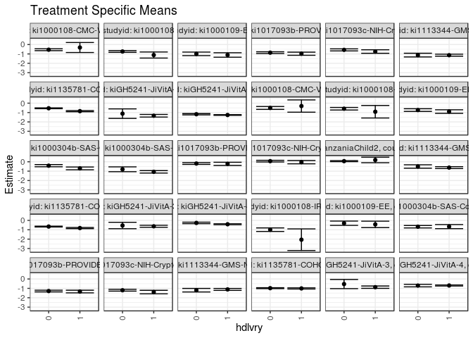

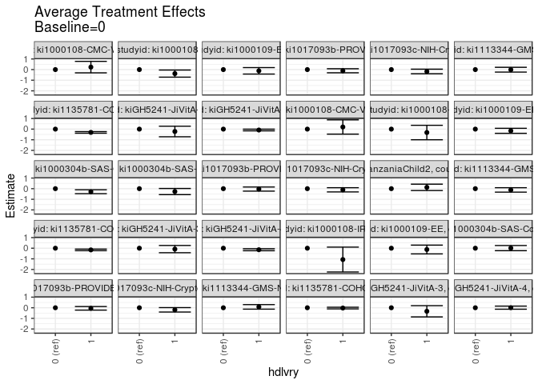

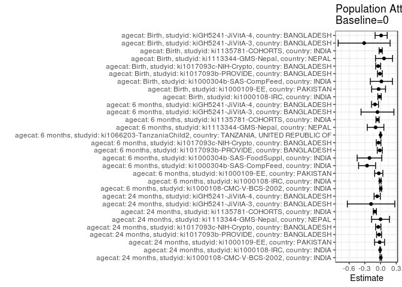

## Results Table

### Parameter: TSM

| agecat | studyid | country | intervention_level | baseline_level | estimate | ci_lower | ci_upper |
| --- | --- | --- | --- | --- | --- | --- | --- |
| Birth | ki1000108-IRC | INDIA | 0 | NA | -0.9918991 | -1.1804921 | -0.8033061 |
| Birth | ki1000108-IRC | INDIA | 1 | NA | -2.0600000 | -3.2141159 | -0.9058841 |
| Birth | ki1000109-EE | PAKISTAN | 0 | NA | -0.3037408 | -0.5318044 | -0.0756772 |
| Birth | ki1000109-EE | PAKISTAN | 1 | NA | -0.4262110 | -0.7681140 | -0.0843081 |
| Birth | ki1000304b-SAS-CompFeed | INDIA | 0 | NA | -0.6740938 | -0.8050105 | -0.5431772 |
| Birth | ki1000304b-SAS-CompFeed | INDIA | 1 | NA | -0.6629343 | -0.8796010 | -0.4462675 |
| Birth | ki1017093b-PROVIDE | BANGLADESH | 0 | NA | -1.2857398 | -1.3772370 | -1.1942426 |
| Birth | ki1017093b-PROVIDE | BANGLADESH | 1 | NA | -1.3385187 | -1.4804910 | -1.1965465 |
| Birth | ki1017093c-NIH-Crypto | BANGLADESH | 0 | NA | -1.1992589 | -1.2931000 | -1.1054178 |
| Birth | ki1017093c-NIH-Crypto | BANGLADESH | 1 | NA | -1.3930234 | -1.5801291 | -1.2059177 |
| Birth | ki1113344-GMS-Nepal | NEPAL | 0 | NA | -1.1950047 | -1.3831427 | -1.0068667 |
| Birth | ki1113344-GMS-Nepal | NEPAL | 1 | NA | -1.1111326 | -1.2126762 | -1.0095891 |
| Birth | ki1135781-COHORTS | INDIA | 0 | NA | -0.9787367 | -1.0258452 | -0.9316282 |
| Birth | ki1135781-COHORTS | INDIA | 1 | NA | -1.0056725 | -1.0680881 | -0.9432568 |
| Birth | kiGH5241-JiVitA-3 | BANGLADESH | 0 | NA | -0.5398409 | -1.0301167 | -0.0495650 |
| Birth | kiGH5241-JiVitA-3 | BANGLADESH | 1 | NA | -0.8715352 | -0.9964861 | -0.7465842 |
| Birth | kiGH5241-JiVitA-4 | BANGLADESH | 0 | NA | -0.7026851 | -0.8387452 | -0.5666250 |
| Birth | kiGH5241-JiVitA-4 | BANGLADESH | 1 | NA | -0.6938739 | -0.7489401 | -0.6388077 |
| 6 months | ki1000108-CMC-V-BCS-2002 | INDIA | 0 | NA | -0.5089262 | -0.6640006 | -0.3538519 |
| 6 months | ki1000108-CMC-V-BCS-2002 | INDIA | 1 | NA | -0.3072917 | -0.9616161 | 0.3470328 |
| 6 months | ki1000108-IRC | INDIA | 0 | NA | -0.5926333 | -0.7305001 | -0.4547666 |
| 6 months | ki1000108-IRC | INDIA | 1 | NA | -0.9137500 | -1.5807163 | -0.2467837 |
| 6 months | ki1000109-EE | PAKISTAN | 0 | NA | -0.7357772 | -0.8777932 | -0.5937613 |
| 6 months | ki1000109-EE | PAKISTAN | 1 | NA | -0.8951332 | -1.0836983 | -0.7065681 |
| 6 months | ki1000304b-SAS-CompFeed | INDIA | 0 | NA | -0.4164458 | -0.5327295 | -0.3001621 |
| 6 months | ki1000304b-SAS-CompFeed | INDIA | 1 | NA | -0.7045253 | -0.8526779 | -0.5563727 |
| 6 months | ki1000304b-SAS-FoodSuppl | INDIA | 0 | NA | -0.8010783 | -1.0577998 | -0.5443568 |
| 6 months | ki1000304b-SAS-FoodSuppl | INDIA | 1 | NA | -1.0719926 | -1.2034974 | -0.9404879 |
| 6 months | ki1017093b-PROVIDE | BANGLADESH | 0 | NA | -0.1849727 | -0.2809229 | -0.0890225 |
| 6 months | ki1017093b-PROVIDE | BANGLADESH | 1 | NA | -0.2216411 | -0.3896268 | -0.0536553 |
| 6 months | ki1017093c-NIH-Crypto | BANGLADESH | 0 | NA | 0.0662241 | -0.0229581 | 0.1554063 |
| 6 months | ki1017093c-NIH-Crypto | BANGLADESH | 1 | NA | -0.0406048 | -0.2168276 | 0.1356180 |
| 6 months | ki1066203-TanzaniaChild2 | TANZANIA, UNITED REPUBLIC OF | 0 | NA | 0.0680238 | 0.0129796 | 0.1230680 |
| 6 months | ki1066203-TanzaniaChild2 | TANZANIA, UNITED REPUBLIC OF | 1 | NA | 0.1932058 | -0.1020565 | 0.4884681 |
| 6 months | ki1113344-GMS-Nepal | NEPAL | 0 | NA | -0.5045819 | -0.6856447 | -0.3235190 |
| 6 months | ki1113344-GMS-Nepal | NEPAL | 1 | NA | -0.6228113 | -0.7239410 | -0.5216816 |
| 6 months | ki1135781-COHORTS | INDIA | 0 | NA | -0.6585824 | -0.7027720 | -0.6143928 |
| 6 months | ki1135781-COHORTS | INDIA | 1 | NA | -0.8168546 | -0.8785307 | -0.7551786 |
| 6 months | kiGH5241-JiVitA-3 | BANGLADESH | 0 | NA | -0.5461683 | -0.8858212 | -0.2065155 |
| 6 months | kiGH5241-JiVitA-3 | BANGLADESH | 1 | NA | -0.6299903 | -0.7405390 | -0.5194417 |
| 6 months | kiGH5241-JiVitA-4 | BANGLADESH | 0 | NA | -0.2702912 | -0.3492061 | -0.1913763 |
| 6 months | kiGH5241-JiVitA-4 | BANGLADESH | 1 | NA | -0.4132818 | -0.4646367 | -0.3619268 |
| 24 months | ki1000108-CMC-V-BCS-2002 | INDIA | 0 | NA | -0.5487673 | -0.6500596 | -0.4474751 |
| 24 months | ki1000108-CMC-V-BCS-2002 | INDIA | 1 | NA | -0.3150000 | -0.8468853 | 0.2168853 |
| 24 months | ki1000108-IRC | INDIA | 0 | NA | -0.7384331 | -0.8312559 | -0.6456103 |
| 24 months | ki1000108-IRC | INDIA | 1 | NA | -1.1158333 | -1.4387631 | -0.7929036 |
| 24 months | ki1000109-EE | PAKISTAN | 0 | NA | -0.9922608 | -1.1801110 | -0.8044106 |
| 24 months | ki1000109-EE | PAKISTAN | 1 | NA | -1.1105150 | -1.3470220 | -0.8740080 |
| 24 months | ki1017093b-PROVIDE | BANGLADESH | 0 | NA | -0.8649601 | -0.9598694 | -0.7700508 |
| 24 months | ki1017093b-PROVIDE | BANGLADESH | 1 | NA | -0.9769689 | -1.1435149 | -0.8104229 |
| 24 months | ki1017093c-NIH-Crypto | BANGLADESH | 0 | NA | -0.5672127 | -0.6776675 | -0.4567580 |
| 24 months | ki1017093c-NIH-Crypto | BANGLADESH | 1 | NA | -0.7449729 | -0.9309155 | -0.5590303 |
| 24 months | ki1113344-GMS-Nepal | NEPAL | 0 | NA | -1.1242452 | -1.3219536 | -0.9265368 |
| 24 months | ki1113344-GMS-Nepal | NEPAL | 1 | NA | -1.1349836 | -1.2408410 | -1.0291261 |
| 24 months | ki1135781-COHORTS | INDIA | 0 | NA | -0.5438405 | -0.5883875 | -0.4992935 |
| 24 months | ki1135781-COHORTS | INDIA | 1 | NA | -0.8513668 | -0.9130987 | -0.7896349 |
| 24 months | kiGH5241-JiVitA-3 | BANGLADESH | 0 | NA | -1.1179521 | -1.6244121 | -0.6114920 |
| 24 months | kiGH5241-JiVitA-3 | BANGLADESH | 1 | NA | -1.3408983 | -1.4814908 | -1.2003058 |
| 24 months | kiGH5241-JiVitA-4 | BANGLADESH | 0 | NA | -1.1784420 | -1.2490476 | -1.1078365 |
| 24 months | kiGH5241-JiVitA-4 | BANGLADESH | 1 | NA | -1.2625331 | -1.3027855 | -1.2222808 |

### Parameter: E(Y)

| agecat | studyid | country | intervention_level | baseline_level | estimate | ci_lower | ci_upper |
| --- | --- | --- | --- | --- | --- | --- | --- |
| Birth | ki1000108-IRC | INDIA | NA | NA | -1.0105831 | -1.1973019 | -0.8238643 |
| Birth | ki1000109-EE | PAKISTAN | NA | NA | -0.3410000 | -0.5302198 | -0.1517802 |
| Birth | ki1000304b-SAS-CompFeed | INDIA | NA | NA | -0.6570846 | -0.8496671 | -0.4645022 |
| Birth | ki1017093b-PROVIDE | BANGLADESH | NA | NA | -1.2984586 | -1.3752758 | -1.2216415 |
| Birth | ki1017093c-NIH-Crypto | BANGLADESH | NA | NA | -1.2441513 | -1.3281130 | -1.1601897 |
| Birth | ki1113344-GMS-Nepal | NEPAL | NA | NA | -1.1277349 | -1.2174865 | -1.0379833 |
| Birth | ki1135781-COHORTS | INDIA | NA | NA | -0.9755867 | -1.0106993 | -0.9404741 |
| Birth | kiGH5241-JiVitA-3 | BANGLADESH | NA | NA | -0.8532192 | -0.9644938 | -0.7419446 |
| Birth | kiGH5241-JiVitA-4 | BANGLADESH | NA | NA | -0.6907341 | -0.7437042 | -0.6377640 |
| 6 months | ki1000108-CMC-V-BCS-2002 | INDIA | NA | NA | -0.5045068 | -0.6566169 | -0.3523968 |
| 6 months | ki1000108-IRC | INDIA | NA | NA | -0.5989297 | -0.7344491 | -0.4634104 |
| 6 months | ki1000109-EE | PAKISTAN | NA | NA | -0.7695800 | -0.8839306 | -0.6552294 |
| 6 months | ki1000304b-SAS-CompFeed | INDIA | NA | NA | -0.6734421 | -0.8121314 | -0.5347528 |
| 6 months | ki1000304b-SAS-FoodSuppl | INDIA | NA | NA | -1.0121579 | -1.1280429 | -0.8962729 |
| 6 months | ki1017093b-PROVIDE | BANGLADESH | NA | NA | -0.1990907 | -0.2817968 | -0.1163845 |
| 6 months | ki1017093c-NIH-Crypto | BANGLADESH | NA | NA | 0.0297622 | -0.0491685 | 0.1086930 |
| 6 months | ki1066203-TanzaniaChild2 | TANZANIA, UNITED REPUBLIC OF | NA | NA | 0.0688763 | 0.0147308 | 0.1230218 |
| 6 months | ki1113344-GMS-Nepal | NEPAL | NA | NA | -0.5992551 | -0.6878945 | -0.5106156 |
| 6 months | ki1135781-COHORTS | INDIA | NA | NA | -0.7160077 | -0.7492815 | -0.6827338 |
| 6 months | kiGH5241-JiVitA-3 | BANGLADESH | NA | NA | -0.6044910 | -0.7122040 | -0.4967781 |
| 6 months | kiGH5241-JiVitA-4 | BANGLADESH | NA | NA | -0.3760651 | -0.4191017 | -0.3330285 |
| 24 months | ki1000108-CMC-V-BCS-2002 | INDIA | NA | NA | -0.5436992 | -0.6434110 | -0.4439874 |
| 24 months | ki1000108-IRC | INDIA | NA | NA | -0.7458150 | -0.8368180 | -0.6548120 |
| 24 months | ki1000109-EE | PAKISTAN | NA | NA | -1.0103892 | -1.1580613 | -0.8627171 |
| 24 months | ki1017093b-PROVIDE | BANGLADESH | NA | NA | -0.8928670 | -0.9755153 | -0.8102187 |
| 24 months | ki1017093c-NIH-Crypto | BANGLADESH | NA | NA | -0.6103502 | -0.7050157 | -0.5156847 |
| 24 months | ki1113344-GMS-Nepal | NEPAL | NA | NA | -1.1238388 | -1.2161263 | -1.0315513 |
| 24 months | ki1135781-COHORTS | INDIA | NA | NA | -0.6520577 | -0.6860033 | -0.6181122 |
| 24 months | kiGH5241-JiVitA-3 | BANGLADESH | NA | NA | -1.2989273 | -1.4377964 | -1.1600583 |
| 24 months | kiGH5241-JiVitA-4 | BANGLADESH | NA | NA | -1.2421463 | -1.2763113 | -1.2079812 |

### Parameter: ATE

| agecat | studyid | country | intervention_level | baseline_level | estimate | ci_lower | ci_upper |
| --- | --- | --- | --- | --- | --- | --- | --- |
| Birth | ki1000108-IRC | INDIA | 0 | 0 | 0.0000000 | 0.0000000 | 0.0000000 |
| Birth | ki1000108-IRC | INDIA | 1 | 0 | -1.0681009 | -2.2375241 | 0.1013224 |
| Birth | ki1000109-EE | PAKISTAN | 0 | 0 | 0.0000000 | 0.0000000 | 0.0000000 |
| Birth | ki1000109-EE | PAKISTAN | 1 | 0 | -0.1224702 | -0.5356044 | 0.2906640 |
| Birth | ki1000304b-SAS-CompFeed | INDIA | 0 | 0 | 0.0000000 | 0.0000000 | 0.0000000 |
| Birth | ki1000304b-SAS-CompFeed | INDIA | 1 | 0 | 0.0111596 | -0.2317793 | 0.2540984 |
| Birth | ki1017093b-PROVIDE | BANGLADESH | 0 | 0 | 0.0000000 | 0.0000000 | 0.0000000 |
| Birth | ki1017093b-PROVIDE | BANGLADESH | 1 | 0 | -0.0527790 | -0.2218025 | 0.1162446 |
| Birth | ki1017093c-NIH-Crypto | BANGLADESH | 0 | 0 | 0.0000000 | 0.0000000 | 0.0000000 |
| Birth | ki1017093c-NIH-Crypto | BANGLADESH | 1 | 0 | -0.1937645 | -0.4031888 | 0.0156599 |
| Birth | ki1113344-GMS-Nepal | NEPAL | 0 | 0 | 0.0000000 | 0.0000000 | 0.0000000 |
| Birth | ki1113344-GMS-Nepal | NEPAL | 1 | 0 | 0.0838721 | -0.1295413 | 0.2972855 |
| Birth | ki1135781-COHORTS | INDIA | 0 | 0 | 0.0000000 | 0.0000000 | 0.0000000 |
| Birth | ki1135781-COHORTS | INDIA | 1 | 0 | -0.0269358 | -0.1049802 | 0.0511087 |
| Birth | kiGH5241-JiVitA-3 | BANGLADESH | 0 | 0 | 0.0000000 | 0.0000000 | 0.0000000 |
| Birth | kiGH5241-JiVitA-3 | BANGLADESH | 1 | 0 | -0.3316943 | -0.8607225 | 0.1973339 |
| Birth | kiGH5241-JiVitA-4 | BANGLADESH | 0 | 0 | 0.0000000 | 0.0000000 | 0.0000000 |
| Birth | kiGH5241-JiVitA-4 | BANGLADESH | 1 | 0 | 0.0088111 | -0.1370342 | 0.1546564 |
| 6 months | ki1000108-CMC-V-BCS-2002 | INDIA | 0 | 0 | 0.0000000 | 0.0000000 | 0.0000000 |
| 6 months | ki1000108-CMC-V-BCS-2002 | INDIA | 1 | 0 | 0.2016346 | -0.4708151 | 0.8740843 |
| 6 months | ki1000108-IRC | INDIA | 0 | 0 | 0.0000000 | 0.0000000 | 0.0000000 |
| 6 months | ki1000108-IRC | INDIA | 1 | 0 | -0.3211167 | -1.0021830 | 0.3599496 |
| 6 months | ki1000109-EE | PAKISTAN | 0 | 0 | 0.0000000 | 0.0000000 | 0.0000000 |
| 6 months | ki1000109-EE | PAKISTAN | 1 | 0 | -0.1593560 | -0.3956263 | 0.0769143 |
| 6 months | ki1000304b-SAS-CompFeed | INDIA | 0 | 0 | 0.0000000 | 0.0000000 | 0.0000000 |
| 6 months | ki1000304b-SAS-CompFeed | INDIA | 1 | 0 | -0.2880795 | -0.4727301 | -0.1034289 |
| 6 months | ki1000304b-SAS-FoodSuppl | INDIA | 0 | 0 | 0.0000000 | 0.0000000 | 0.0000000 |
| 6 months | ki1000304b-SAS-FoodSuppl | INDIA | 1 | 0 | -0.2709143 | -0.5600337 | 0.0182050 |
| 6 months | ki1017093b-PROVIDE | BANGLADESH | 0 | 0 | 0.0000000 | 0.0000000 | 0.0000000 |
| 6 months | ki1017093b-PROVIDE | BANGLADESH | 1 | 0 | -0.0366684 | -0.2307557 | 0.1574189 |
| 6 months | ki1017093c-NIH-Crypto | BANGLADESH | 0 | 0 | 0.0000000 | 0.0000000 | 0.0000000 |
| 6 months | ki1017093c-NIH-Crypto | BANGLADESH | 1 | 0 | -0.1068288 | -0.3054265 | 0.0917688 |
| 6 months | ki1066203-TanzaniaChild2 | TANZANIA, UNITED REPUBLIC OF | 0 | 0 | 0.0000000 | 0.0000000 | 0.0000000 |
| 6 months | ki1066203-TanzaniaChild2 | TANZANIA, UNITED REPUBLIC OF | 1 | 0 | 0.1251820 | -0.1750373 | 0.4254012 |
| 6 months | ki1113344-GMS-Nepal | NEPAL | 0 | 0 | 0.0000000 | 0.0000000 | 0.0000000 |
| 6 months | ki1113344-GMS-Nepal | NEPAL | 1 | 0 | -0.1182294 | -0.3259192 | 0.0894603 |
| 6 months | ki1135781-COHORTS | INDIA | 0 | 0 | 0.0000000 | 0.0000000 | 0.0000000 |
| 6 months | ki1135781-COHORTS | INDIA | 1 | 0 | -0.1582722 | -0.2339739 | -0.0825705 |
| 6 months | kiGH5241-JiVitA-3 | BANGLADESH | 0 | 0 | 0.0000000 | 0.0000000 | 0.0000000 |
| 6 months | kiGH5241-JiVitA-3 | BANGLADESH | 1 | 0 | -0.0838220 | -0.4259312 | 0.2582872 |
| 6 months | kiGH5241-JiVitA-4 | BANGLADESH | 0 | 0 | 0.0000000 | 0.0000000 | 0.0000000 |
| 6 months | kiGH5241-JiVitA-4 | BANGLADESH | 1 | 0 | -0.1429905 | -0.2351754 | -0.0508056 |
| 24 months | ki1000108-CMC-V-BCS-2002 | INDIA | 0 | 0 | 0.0000000 | 0.0000000 | 0.0000000 |
| 24 months | ki1000108-CMC-V-BCS-2002 | INDIA | 1 | 0 | 0.2337673 | -0.3076771 | 0.7752117 |
| 24 months | ki1000108-IRC | INDIA | 0 | 0 | 0.0000000 | 0.0000000 | 0.0000000 |
| 24 months | ki1000108-IRC | INDIA | 1 | 0 | -0.3774002 | -0.7134057 | -0.0413948 |
| 24 months | ki1000109-EE | PAKISTAN | 0 | 0 | 0.0000000 | 0.0000000 | 0.0000000 |
| 24 months | ki1000109-EE | PAKISTAN | 1 | 0 | -0.1182542 | -0.4218787 | 0.1853703 |
| 24 months | ki1017093b-PROVIDE | BANGLADESH | 0 | 0 | 0.0000000 | 0.0000000 | 0.0000000 |
| 24 months | ki1017093b-PROVIDE | BANGLADESH | 1 | 0 | -0.1120088 | -0.3029282 | 0.0789106 |
| 24 months | ki1017093c-NIH-Crypto | BANGLADESH | 0 | 0 | 0.0000000 | 0.0000000 | 0.0000000 |
| 24 months | ki1017093c-NIH-Crypto | BANGLADESH | 1 | 0 | -0.1777602 | -0.3938806 | 0.0383603 |
| 24 months | ki1113344-GMS-Nepal | NEPAL | 0 | 0 | 0.0000000 | 0.0000000 | 0.0000000 |
| 24 months | ki1113344-GMS-Nepal | NEPAL | 1 | 0 | -0.0107384 | -0.2358132 | 0.2143365 |
| 24 months | ki1135781-COHORTS | INDIA | 0 | 0 | 0.0000000 | 0.0000000 | 0.0000000 |
| 24 months | ki1135781-COHORTS | INDIA | 1 | 0 | -0.3075263 | -0.3835086 | -0.2315440 |
| 24 months | kiGH5241-JiVitA-3 | BANGLADESH | 0 | 0 | 0.0000000 | 0.0000000 | 0.0000000 |
| 24 months | kiGH5241-JiVitA-3 | BANGLADESH | 1 | 0 | -0.2229462 | -0.7206807 | 0.2747882 |
| 24 months | kiGH5241-JiVitA-4 | BANGLADESH | 0 | 0 | 0.0000000 | 0.0000000 | 0.0000000 |
| 24 months | kiGH5241-JiVitA-4 | BANGLADESH | 1 | 0 | -0.0840911 | -0.1642238 | -0.0039584 |

### Parameter: PAR

| agecat | studyid | country | intervention_level | baseline_level | estimate | ci_lower | ci_upper |
| --- | --- | --- | --- | --- | --- | --- | --- |
| Birth | ki1000108-IRC | INDIA | 0 | NA | -0.0186840 | -0.0514705 | 0.0141025 |
| Birth | ki1000109-EE | PAKISTAN | 0 | NA | -0.0372592 | -0.1699794 | 0.0954609 |
| Birth | ki1000304b-SAS-CompFeed | INDIA | 0 | NA | 0.0170092 | -0.1942499 | 0.2282683 |
| Birth | ki1017093b-PROVIDE | BANGLADESH | 0 | NA | -0.0127189 | -0.0587025 | 0.0332648 |
| Birth | ki1017093c-NIH-Crypto | BANGLADESH | 0 | NA | -0.0448924 | -0.0923406 | 0.0025557 |
| Birth | ki1113344-GMS-Nepal | NEPAL | 0 | NA | 0.0672698 | -0.0958918 | 0.2304315 |
| Birth | ki1135781-COHORTS | INDIA | 0 | NA | 0.0031500 | -0.0274433 | 0.0337433 |
| Birth | kiGH5241-JiVitA-3 | BANGLADESH | 0 | NA | -0.3133783 | -0.8100583 | 0.1833017 |
| Birth | kiGH5241-JiVitA-4 | BANGLADESH | 0 | NA | 0.0119510 | -0.1036931 | 0.1275952 |
| 6 months | ki1000108-CMC-V-BCS-2002 | INDIA | 0 | NA | 0.0044194 | -0.0126632 | 0.0215020 |
| 6 months | ki1000108-IRC | INDIA | 0 | NA | -0.0062964 | -0.0238639 | 0.0112711 |
| 6 months | ki1000109-EE | PAKISTAN | 0 | NA | -0.0338028 | -0.1117918 | 0.0441863 |
| 6 months | ki1000304b-SAS-CompFeed | INDIA | 0 | NA | -0.2569963 | -0.4195721 | -0.0944205 |
| 6 months | ki1000304b-SAS-FoodSuppl | INDIA | 0 | NA | -0.2110796 | -0.4471225 | 0.0249633 |
| 6 months | ki1017093b-PROVIDE | BANGLADESH | 0 | NA | -0.0141179 | -0.0626678 | 0.0344320 |
| 6 months | ki1017093c-NIH-Crypto | BANGLADESH | 0 | NA | -0.0364618 | -0.0807538 | 0.0078302 |
| 6 months | ki1066203-TanzaniaChild2 | TANZANIA, UNITED REPUBLIC OF | 0 | NA | 0.0008525 | -0.0064155 | 0.0081205 |
| 6 months | ki1113344-GMS-Nepal | NEPAL | 0 | NA | -0.0946732 | -0.2531337 | 0.0637873 |
| 6 months | ki1135781-COHORTS | INDIA | 0 | NA | -0.0574252 | -0.0876113 | -0.0272392 |
| 6 months | kiGH5241-JiVitA-3 | BANGLADESH | 0 | NA | -0.0583227 | -0.3724318 | 0.2557864 |
| 6 months | kiGH5241-JiVitA-4 | BANGLADESH | 0 | NA | -0.1057738 | -0.1723014 | -0.0392462 |
| 24 months | ki1000108-CMC-V-BCS-2002 | INDIA | 0 | NA | 0.0050681 | -0.0089078 | 0.0190440 |
| 24 months | ki1000108-IRC | INDIA | 0 | NA | -0.0073819 | -0.0171941 | 0.0024303 |
| 24 months | ki1000109-EE | PAKISTAN | 0 | NA | -0.0181284 | -0.1135746 | 0.0773178 |
| 24 months | ki1017093b-PROVIDE | BANGLADESH | 0 | NA | -0.0279069 | -0.0758511 | 0.0200373 |
| 24 months | ki1017093c-NIH-Crypto | BANGLADESH | 0 | NA | -0.0431375 | -0.0943762 | 0.0081012 |
| 24 months | ki1113344-GMS-Nepal | NEPAL | 0 | NA | 0.0004064 | -0.1710296 | 0.1718424 |
| 24 months | ki1135781-COHORTS | INDIA | 0 | NA | -0.1082173 | -0.1380734 | -0.0783612 |
| 24 months | kiGH5241-JiVitA-3 | BANGLADESH | 0 | NA | -0.1809753 | -0.6346801 | 0.2727295 |
| 24 months | kiGH5241-JiVitA-4 | BANGLADESH | 0 | NA | -0.0637042 | -0.1231729 | -0.0042355 |